# 3. Text_Preprocessing_and_Pipelines_in_SparkNLP

## 3. Text Preprocessing with Spark NLP

- **Introduction to Text Preprocessing Sprak NLP**
- **Spark2.3 set up**
- **Creating Spark DF with Text**
- **Annotators and Transformers in Spark NLP**
- **Document Assembler**
- **Sentense Detector**
- **Sentense Detector Deep Learning**
- **Tokenizer**
- **Normalizer**
- **StopwordsCleaner**
- **SlangCleaner**
- **Spell Checker**
- **TokenAssembler**
- **Stemmer**
- **Lemmetization**
- **Text Cleanig with UDF**
- **PerceptronModel (POS - Part of speech tags)**
- **Stacking Spark NLP Annotators in Spark ML Pipeline**
- **Finisher**
- **SparkNLP Lite Pipeline**

### Introduction to Text Preprocessing Spark NLP

All Annotators in Spark NLP are either **Estimators or Transformers** as we see in Spark ML.

- An Estimator in Spark ML is an algorithm which can be fit on a DataFrame to produce a Transformer. E.g., a learning algorithm is an Estimator which trains on a DataFrame and produces a model. A Transformer is an algorithm which can transform one DataFrame into another DataFrame. E.g., an ML model is a Transformer that transforms a DataFrame with features into a DataFrame with predictions.

There are two types of annotators: AnnotatorApproach and AnnotatorModel

- **Annotator Approaches:** Are those who represent a Spark ML Estimator and require a training stage. They have a function called fit(data) which trains a model based on some data. They produce the second type of annotator which is an annotator model or transformer.
- **Annotator Model:** They are spark models or transformers, meaning they have a transform(data) function which take a dataset and add to it a column with the result of this annotation. All transformers are additive, meaning they append to current data, never replace or delete previous information.

Both forms of annotators can be included in a Pipeline and will automatically go through all stages in the provided order and transform the data accordingly. A Pipeline is turned into a PipelineModel after the fit() stage. Either before or after can be saved and re-loaded to disk at any time.

By convention, there are three possible names:

- Approach — Trainable annotator
- Model — Trained annotator
- Nothing — A non-trainable annotator with pre-processing

So for example, Stemmer doesn’t say Approach nor Model, however, it is a Model. On the other hand, Tokenizer doesn’t say Approach nor Model, but it has a TokenizerModel(). Because it is not “training” anything, but it is doing some preprocessing before converting into a Model. Hence Tokenizer is an AnnotatorApproach and we need to call fit() and then transform().

Reference: https://towardsdatascience.com/introduction-to-spark-nlp-foundations-and-basic-components-part-i-c83b7629ed59

### Spark2.3 set up

```python
#loading jar path
from utils import pathbuilder
jar_path=pathbuilder.load_jarpath()

#initializing spark session
from pyspark.sql import SparkSession
spark = SparkSession.builder \
        .appName("Spark NLP") \
        .master("local[*]") \
        .config("spark.driver.memory", "16G") \
        .config("spark.serializer", "org.apache.spark.serializer.KryoSerializer") \
        .config("spark.kryoserializer.buffer.max", "1000M") \
        .config("spark.driver.maxResultSize", "0")\
        .config("spark.jars", "{}spark-nlp-spark23-assembly-2.6.2.jar,{}spark-nlp-jsl-2.6.2-spark23.jar".format(jar_path,jar_path)) \
        .getOrCreate()

#importing dependencies
import sparknlp
from sparknlp.pretrained import PretrainedPipeline
from sparknlp.annotator import *
from sparknlp_jsl.annotator import *
from sparknlp.base import *
import sparknlp_jsl
import pyspark.sql.functions as f
print('spark NLP version: ',sparknlp.version())
print('spark version:',spark.version)
```

```
spark NLP version:  2.6.2
spark version: 2.3.0
```

### Creating Spark Dataframe with Text

```python
text ='The patient was prescribed 1 capsule of Advil for 5 days. He was seen by the endocrinology service and she was discharged on 40 units of insulin glargine at night, 12 units of insulin lispro with meals, and metformin 1000 mg two times a day. It was determined that all SGLT2 inhibitors should be discontinued indefinitely fro 3 months.'
spark_df = spark.createDataFrame([[text]]).toDF("text")
spark_df.show(truncate=100)
```

```
+----------------------------------------------------------------------------------------------------+
|                                                                                                text|
+----------------------------------------------------------------------------------------------------+
|The patient was prescribed 1 capsule of Advil for 5 days. He was seen by the endocrinology servic...|
+----------------------------------------------------------------------------------------------------+
```

### Annotators and Transformer in Spark NLP

Now Let examine how Text preprocessing can be done in Spark NLP using Annotators and Transformers. Assume that we have the following steps that need to be applied one by one on a data frame.

- Split text into sentences
- Tokenize
- Normalize
- Get word embeddings

There are many **[Annotators](https://nlp.johnsnowlabs.com/docs/en/annotators)** in Spark NLP. In text preprocessing, we use majorly DocumentAssembler(), SentenceDatector(),Tokenizer(),Normalizer() and WordEmbeddings()

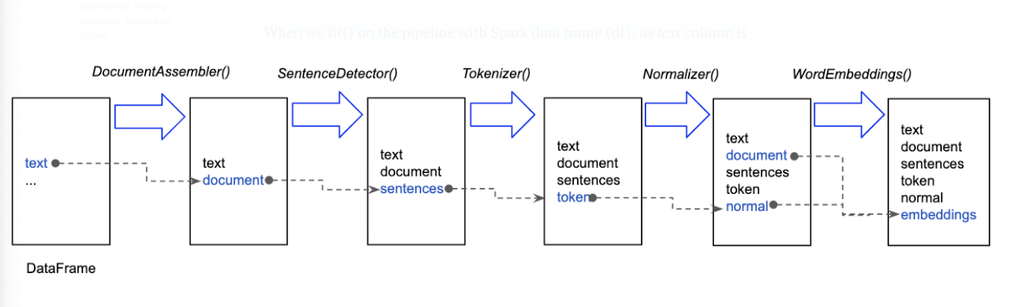

**What’s actually happening under the hood of above pipeline?**

**Every Annotator and Transformer will have**

- setInputCols(column_names): Takes a list of column names of annotations required by this annotator
- setOutputCol(column_name): Defines the name of the column containing the result of this annotator. Use this name as an input for other annotators requiring the annotations of this one.

### Document Assembler

In order to get through the NLP process, we need to get raw data annotated. There is a special transformer that does this for us: the DocumentAssembler, it creates the first annotation of type Document which may be used by annotators down the road

```python
from sparknlp.base import DocumentAssembler
documentAssembler = DocumentAssembler()\
.setInputCol("text")\
.setOutputCol("document")\
.setCleanupMode("shrink")
doc_df = documentAssembler.transform(spark_df)
doc_df.show(truncate=30)
```

```
+------------------------------+------------------------------+
|                          text|                      document|
+------------------------------+------------------------------+
|The patient was prescribed ...|[[document, 0, 334, The pat...|
+------------------------------+------------------------------+
```

```python
# Check the schema of Doc DF
doc_df.printSchema()
```

```
root
 |-- text: string (nullable = true)
 |-- document: array (nullable = true)
 |    |-- element: struct (containsNull = true)
 |    |    |-- annotatorType: string (nullable = true)
 |    |    |-- begin: integer (nullable = false)
 |    |    |-- end: integer (nullable = false)
 |    |    |-- result: string (nullable = true)
 |    |    |-- metadata: map (nullable = true)
 |    |    |    |-- key: string
 |    |    |    |-- value: string (valueContainsNull = true)
 |    |    |-- embeddings: array (nullable = true)
 |    |    |    |-- element: float (containsNull = false)
```

```python
doc_df.select('document.result','document.begin','document.end').show(truncate=100)
```

```
+----------------------------------------------------------------------------------------------------+-----+-----+
|                                                                                              result|begin|  end|
+----------------------------------------------------------------------------------------------------+-----+-----+
|[The patient was prescribed 1 capsule of Advil for 5 days. He was seen by the endocrinology servi...|  [0]|[334]|
+----------------------------------------------------------------------------------------------------+-----+-----+
```

### Sentence Detector

Now, we proceed to identify the sentences in each of our document lines. SentenceDetector requires a Document annotation, which is provided by the DocumentAssembler output, and it’s itself a Document type token. The Tokenizer requires a Document annotation type, meaning it works both with DocumentAssembler or SentenceDetector output, in here, we use the sentence output

**Settable parameters**

- `setCustomBounds(string)`: Custom sentence separator text e.g. `["\n"]`
- `setUseCustomOnly(bool)`: Use only custom bounds without considering those of Pragmatic Segmenter. Defaults to false. Needs customBounds.
- `setUseAbbreviations(bool)`: Whether to consider abbreviation strategies for better accuracy but slower performance. Defaults to true.
- `setExplodeSentences(bool)`: Whether to split sentences into different Dataset rows. Useful for higher parallelism in fat rows. Defaults to false.

```python
# we feed the document column coming from Document Assembler
sentenceDetector = SentenceDetector().\
                setInputCols(['document']).\
                setOutputCol('sentence')
```

```python
sent_df = sentenceDetector.transform(doc_df) #default input coulumn is document and output is sentences
sent_df.show(truncate=40)
```

```
+----------------------------------------+----------------------------------------+----------------------------------------+
|                                    text|                                document|                                sentence|
+----------------------------------------+----------------------------------------+----------------------------------------+
|The patient was prescribed 1 capsule ...|[[document, 0, 334, The patient was p...|[[document, 0, 56, The patient was pr...|
+----------------------------------------+----------------------------------------+----------------------------------------+
```

### Sentence Detector DL

```python
#Detecting sentences using deep learning pretrained model
```

```python
# sentencerDL = SentenceDetectorDLModel\
#   .load("sentence_detector_dl", "en") \
#   .setInputCols(["document"]) \
#   .setOutputCol("sentences")a

# sent_dl_df = sentencerDL.transform(doc_df)
# sent_dl_df.select(F.explode('sentences.result')).show(truncate=False)
```

### Tokenizer

Identifies tokens with tokenization open standards. It is an **Annotator Approach, so it requires .fit()**. A few rules will help customizing it if defaults do not fit user needs.

- `setExceptions(StringArray)`: List of tokens to not alter at all. Allows composite tokens like two worded tokens that the user may not want to split.
- `addException(String)`: Add a single exception
- `setExceptionsPath(String)`: Path to txt file with list of token exceptions
- `caseSensitiveExceptions(bool)`: Whether to follow case sensitiveness for matching exceptions in text
- `contextChars(StringArray)`: List of 1 character string to rip off from tokens, such as parenthesis or question marks. Ignored if using prefix, infix or suffix patterns.
- `splitChars(StringArray)`: List of 1 character string to split tokens inside, such as hyphens. Ignored if using infix, prefix or suffix patterns.
- `splitPattern (String)`: pattern to separate from the inside of tokens. takes priority over splitChars.setTargetPattern: Basic regex rule to identify a candidate for tokenization. Defaults to \S+ which means anything not a space
- `setSuffixPattern`: Regex to identify subtokens that are in the end of the token. Regex has to end with \z and must contain groups (). Each group will become a separate token within the prefix. Defaults to non-letter characters. e.g. quotes or parenthesis
- `setPrefixPattern`: Regex to identify subtokens that come in the beginning of the token. Regex has to start with \A and must contain groups (). Each group will become a separate token within the prefix. Defaults to non-letter characters. e.g. quotes or parenthesis
- `addInfixPattern`: Add an extension pattern regex with groups to the top of the rules (will target first, from more specific to the more general).
- `minLength`: Set the minimum allowed legth for each token
- `maxLength`: Set the maximum allowed legth for each token

```python
# Tokeniser can be done on documents or on sentenses
tokenizer = Tokenizer() \
    .setInputCols(["sentence"]) \
    .setOutputCol("token")
```

```python
token_df = tokenizer.fit(sent_df).transform(sent_df)
token_df.select(f.explode('token.result')).show(truncate=False,n=5)
```

```
+----------+
|col       |
+----------+
|The       |
|patient   |
|was       |
|prescribed|
|1         |
+----------+
only showing top 5 rows
```

### Normalizer

Removes all dirty characters from text following a regex pattern and transforms words based on a provided dictionary

- `setCleanupPatterns(patterns)`: Regular expressions list for normalization, defaults [^A-Za-z]
- `setLowercase(value)`: lowercase tokens, default false
- `setSlangDictionary(path)`: txt file with delimited words to be transformed into something else

```python
import string
string.punctuation
```

```
'!"#$%&\'()*+,-./:;<=>?@[\\]^_`{|}~'
```

```python
normalizer = Normalizer() \
    .setInputCols(["token"]) \
    .setOutputCol("normalized")\
    .setLowercase(True)\
    .setCleanupPatterns(["[^\w\d\s]"]) # remove punctuations (keep alphanumeric chars)
    # if we don't set CleanupPatterns, it will only keep alphabet letters ([^A-Za-z])
```

```python
norm_df=normalizer.fit(token_df).transform(token_df)
norm_df.select(F.explode('normalized.result')).show(truncate=False,n=5)
```

```
+----------+
|col       |
+----------+
|the       |
|patient   |
|was       |
|prescribed|
|1         |
+----------+
only showing top 5 rows
```

### Slang Cleaner

```python
from sparknlp.pretrained import PretrainedPipeline
clean_slang = PretrainedPipeline.from_disk('/data/spark_nlp/pretrained/pipelines/clean_slang_en/')
result_clean_slang = clean_slang.annotate(' Whatsup bro, call me ASAP')
print(' '.join(result_clean_slang['normal']))
```

```
how are you friend call me as soon as possible
```

### Spell Checker

refer https://norvig.com/spell-correct.html for more information

```python
#Loading spell checker model from a local disk
model_path=pathbuilder.load_pretrained_model_path('check_spelling_en')
spell_checker_ml = PretrainedPipeline.from_disk(model_path)
```

```python
#text with spelling mistkes for testing spelling checker model
text_spell_check = '''
He is a  good persn.
My life  is very intersting.
'''
```

```python
# Displaying the results
import pandas as pd
result_spell_checker_ml = spell_checker_ml.annotate(text_spell_check)
pd.DataFrame({'word':result_spell_checker_ml['token'],"corrected_word":result_spell_checker_ml['checked']}).head(5)
```

|  | word | corrected_word |
| --- | --- | --- |
| 0 | He | He |
| 1 | is | is |
| 2 | a | a |
| 3 | good | good |
| 4 | persn | person |

### Stopwords Cleaner

This annotator excludes from a sequence of strings (e.g. the output of a Tokenizer, Normalizer, Lemmatizer, and Stemmer) and drops all the stop words from the input sequences. Functions:

- **`setStopWords`**: The words to be filtered out. Array[String]
- **`setCaseSensitive`**: Whether to do a case sensitive comparison over the stop words.

```python
#Initializing stop words cleaner
stop_words_cleaner = StopWordsCleaner() \
        .setInputCols(["normalized"]) \
        .setOutputCol("cleanTokens") \
        .setCaseSensitive(False) \
```

```python
#what are the stop words
stop_words_cleaner.getStopWords()
```

```
['i',
 'me',
 'my',
 'myself',
 'we',
 'our',
 'ours',
 'ourselves',
 'you',
 'your',
 'yours',
 'yourself',
 'yourselves',
 'he',
 'him',
 'his',
 'himself',
 'she',
 'her',
 'hers',
 'herself',
 'it',
 'its',
 'itself',
 'they',
 'them',
 'their',
 'theirs',
 'themselves',
 'what',
 'which',
 'who',
 'whom',
 'this',
 'that',
 'these',
 'those',
 'am',
 'is',
 'are',
```

[output cut: 126 more lines]

```
 "couldn't",
 'cannot',
 'could',
 "here's",
 "how's",
 "let's",
 'ought',
 "that's",
 "there's",
 "what's",
 "when's",
 "where's",
 "who's",
 "why's",
 'would']
```

```python
# removing the stop words
stop_words_df = stop_words_cleaner.transform(norm_df)
stop_words_df.select(F.explode('cleanTokens.result')).show(truncate=False,n=5)
```

```
+----------+
|col       |
+----------+
|patient   |
|prescribed|
|1         |
|capsule   |
|advil     |
+----------+
only showing top 5 rows
```

### Token Assembler

```python
#Initializing Token Assembler
from sparknlp.base import TokenAssembler
tokenassembler = TokenAssembler()\
    .setInputCols(["sentence", "cleanTokens"]) \
    .setOutputCol("clean_text")
```

```python
# combing tokens
token_assemb_df=tokenassembler.transform(stop_words_df)
token_assemb_df.select(F.explode('clean_text.result')).show(truncate=100)
```

```
+----------------------------------------------------------------------------------------------------+
|                                                                                                 col|
+----------------------------------------------------------------------------------------------------+
|                                                           patient prescribed 1 capsule advil 5 days|
|seen endocrinology service discharged 40 units insulin glargine night 12 units insulin lispro mea...|
|                                  determined sglt2 inhibitors discontinued indefinitely fro 3 months|
+----------------------------------------------------------------------------------------------------+
```

### Stemmer

Returns hard-stems out of words with the objective of retrieving the meaningful part of the word

- **Output type: Token**
- **Input types: Token**

```python
#Initializing Stemmer
stemmer = Stemmer() \
    .setInputCols(["cleanTokens"]) \
    .setOutputCol("stem")
```

```python
# stemming the words
stem_df=stemmer.transform(stop_words_df)
stem_df.select('cleanTokens.result','stem.result').show(truncate=50)
```

```
+--------------------------------------------------+--------------------------------------------------+
|                                            result|                                            result|
+--------------------------------------------------+--------------------------------------------------+
|[patient, prescribed, 1, capsule, advil, 5, day...|[patient, prescrib, 1, capsul, advil, 5, dai, s...|
+--------------------------------------------------+--------------------------------------------------+
```

### Lemmatizer

Retrieves lemmas out of words with the objective of returning a base dictionary word

- **Output type: Token**
- **Input types: Token**

we can set dictitonary for lemmatization. Example dictionary can be found here

- ref: https://raw.githubusercontent.com/mahavivo/vocabulary/master/lemmas/AntBNC_lemmas_ver_001.txt

**Lemmatization using classical method**

```python
lemmatizer = Lemmatizer() \
    .setInputCols(["cleanTokens"]) \
    .setOutputCol("lemma") \
    .setDictionary("./Data/AntBNC_lemmas_ver_001.txt", value_delimiter ="\t", key_delimiter = "->")
```

```python
lem_df=lemmatizer.fit(stop_words_df).transform(stop_words_df)
lem_df.select('cleanTokens.result','lemma.result').show(truncate=50)
```

```
+--------------------------------------------------+--------------------------------------------------+
|                                            result|                                            result|
+--------------------------------------------------+--------------------------------------------------+
|[patient, prescribed, 1, capsule, advil, 5, day...|[patient, prescribe, 1, capsule, advil, 5, day,...|
+--------------------------------------------------+--------------------------------------------------+
```

**Lemmatization using Pretrained Deep Learning model**

```python
model_path=pathbuilder.load_pretrained_model_path('lemma_antbnc_en_2.0.2_2.4')
lem_model=LemmatizerModel.load(model_path)\
    .setInputCols(["cleanTokens"]) \
    .setOutputCol("lemma_model") \
```

```python
lem_model_df=lem_model.transform(stop_words_df)
lem_model_df.select('cleanTokens.result','lemma_model.result').show(truncate=50)
```

```
+--------------------------------------------------+--------------------------------------------------+
|                                            result|                                            result|
+--------------------------------------------------+--------------------------------------------------+
|[patient, prescribed, 1, capsule, advil, 5, day...|[patient, prescribe, 1, capsule, advil, 5, day,...|
+--------------------------------------------------+--------------------------------------------------+
```

### Text Cleaning with UDF

We can define user defined function for text preprocessing. Following example shows, how the text is extracted from html tags

```python
#defining junk text for preprocessing using udf
text = '<h1 style="color: #5e9ca0;">Have a great <span  style="color: #2b2301;">birth</span> day!</h1>'
text_df = spark.createDataFrame([[text]]).toDF("text")
```

```python
#importing libraries
import re
from pyspark.sql.functions import udf
from pyspark.sql.types import StringType, IntegerType

#defining the user defined functions
clean_text = lambda s: re.sub(r'<[^>]*>', '', s)
text_df.withColumn('cleaned', udf(clean_text, StringType())('text')).select('text','cleaned').show(truncate= False)
```

```
+----------------------------------------------------------------------------------------------+-----------------------+
|text                                                                                          |cleaned                |
+----------------------------------------------------------------------------------------------+-----------------------+
|<h1 style="color: #5e9ca0;">Have a great <span  style="color: #2b2301;">birth</span> day!</h1>|Have a great birth day!|
+----------------------------------------------------------------------------------------------+-----------------------+
```

### PerceptronModel (POS - Part of speech tags)

Sets a POS tag to each word within a sentence. Its train data (train_pos) is a spark dataset of POS format values with Annotation columns.

- `Output type:` POS
- `Input types:` Document, Token

Functions:

- `setNIterations(number):` Number of iterations for training. May improve accuracy but takes longer. Default 5.
- `setPosColumn(colname):` Column containing an array of POS Tags matching every token on the line.

```python
# what are POS acronyms
import pandas as pd
pos_df= pd.read_csv('./Data/POS_En.csv',sep=';',)
pos_df
```

|  | Number | Tag | Description |
| --- | --- | --- | --- |
| 0 | 1.0 | CC | Coordinating conjunction |
| 1 | 2.0 | CD | Cardinal number |
| 2 | 3.0 | DT | Determiner |
| 3 | 4.0 | EX | Existential there |
| 4 | 5.0 | FW | Foreign word |
| 5 | 6.0 | IN | Preposition or subordinating conjunction |
| 6 | 7.0 | JJ | Adjective |
| 7 | 8.0 | JJR | Adjective, comparative |
| 8 | 9.0 | JJS | Adjective, superlative |
| 9 | 10.0 | LS | List item marker |
| 10 | 11.0 | MD | Modal |
| 11 | 12.0 | NN | Noun, singular or mass |
| 12 | 13.0 | NNS | Noun, plural |
| 13 | 14.0 | NNP | Proper noun, singular |
| 14 | 15.0 | NNPS | Proper noun, plural |
| 15 | 16.0 | PDT | Predeterminer |
| 16 | 17.0 | POS | Possessive ending |
| 17 | 18.0 | PRP | Personal pronoun |
| 18 | 19.0 | PRP$ | Possessive pronoun |
| 19 | 20.0 | RB | Adverb |
| 20 | 21.0 | RBR | Adverb, comparative |
| 21 | 22.0 | RBS | Adverb, superlative |
| 22 | 23.0 | RP | Particle |
| 23 | 24.0 | SYM | Symbol |
| 24 | 25.0 | TO | to |
| 25 | 26.0 | UH | Interjection |
| 26 | 27.0 | VB | Verb, base form |
| 27 | 28.0 | VBD | Verb, past tense |
| 28 | 29.0 | VBG | Verb, gerund or present participle |
| 29 | 30.0 | VBN | Verb, past participle |
| 30 | 31.0 | VBP | Verb, non-3rd person singular present |
| 31 | 32.0 | VBZ | Verb, 3rd person singular present |
| 32 | 33.0 | WDT | Wh-determiner |
| 33 | 34.0 | WP | Wh-pronoun |
| 34 | 35.0 | WP$ | Possessive wh-pronoun |
| 35 | 36.0 | WRB | Wh-adverb |

```python
#loading POS model
from sparknlp.pretrained import PerceptronModel
model_path=pathbuilder.load_pretrained_model_path('pos_anc_en_2.0.2_2.4')
pos_anc = PerceptronModel.load(model_path)\
      .setInputCols("document", "token")\
      .setOutputCol("pos")
```

```python
#predicting POS
pos_df=pos_anc.transform(token_df)
pos_df.select('token.result','pos.result').show(truncate=50)
```

```
+--------------------------------------------------+--------------------------------------------------+
|                                            result|                                            result|
+--------------------------------------------------+--------------------------------------------------+
|[The, patient, was, prescribed, 1, capsule, of,...|[DT, NN, VBD, VBN, CD, NN, IN, NNP, IN, CD, NNS...|
+--------------------------------------------------+--------------------------------------------------+
```

```python
# POS UD MODEL
model_path=pathbuilder.load_pretrained_model_path('pos_ud_ewt_en_2.2.2_2.4')
pos_ud_ewt_df = PerceptronModel.load(model_path)\
      .setInputCols("document", "token")\
      .setOutputCol("pos")
#predicting POS
pos_ud_ewt_df=pos_ud_ewt_df.transform(token_df)
pos_ud_ewt_df.select('token.result','pos.result').show(truncate=50)
```

```
+--------------------------------------------------+--------------------------------------------------+
|                                            result|                                            result|
+--------------------------------------------------+--------------------------------------------------+
|[The, patient, was, prescribed, 1, capsule, of,...|[DET, NOUN, AUX, VERB, NUM, NOUN, ADP, PROPN, A...|
+--------------------------------------------------+--------------------------------------------------+
```

### DependencyParserModel

Unlabeled parser that finds a grammatical relation between two words in a sentence. Its input is a directory with dependency treebank files.

- `Output type:` Dependency
- `Input types:` Document, POS, Token

Functions

- `setNumberOfIterations:` Number of iterations in training, converges to better accuracy
- `setDependencyTreeBank:` Dependency treebank folder with files in Penn Treebank format
- `conllU:` Path to a file in [CoNLL-U format](https://universaldependencies.org/format.html)

```python
#loading untyped dependency_conllu froma local disk
model_path=pathbuilder.load_pretrained_model_path('dependency_conllu_en_2.0.8_2.4')
dependency_parser = DependencyParserModel.load(model_path)\
            .setInputCols(["sentence", "pos", "token"]) \
            .setOutputCol("dependency")
# predicing dependencies
dependency_parser_df=dependency_parser.transform(pos_ud_ewt_df)
dependency_parser_df.select('dependency.result').show(truncate=100)
```

```
+----------------------------------------------------------------------------------------------------+
|                                                                                              result|
+----------------------------------------------------------------------------------------------------+
|[patient, prescribed, prescribed, ROOT, capsule, prescribed, Advil, capsule, days, days, capsule,...|
+----------------------------------------------------------------------------------------------------+
```

### Typed Dependency Parse

Labeled parser that finds a grammatical relation between two words in a sentence. Its input is a CoNLL2009 or ConllU dataset.

- `Output type:` Labeled Dependency
- `Input types:` Token, POS, Dependency

Functions:

- `setNumberOfIterations:` Number of iterations in training, converges to better accuracy
- `setConll2009:` Path to a file in [CoNLL 2009 format](https://ufal.mff.cuni.cz/conll2009-st/trial-data.html)
- `setConllU:` Path to a file in [CoNLL-U format](https://universaldependencies.org/format.html)

```python
#loading typed dependency_conllu froma local disk
model_path=pathbuilder.load_pretrained_model_path('dependency_typed_conllu_en_2.0.8_2.4')
typed_dependency_parser =TypedDependencyParserModel.load(model_path)\
            .setInputCols(["dependency", "pos", "token"]) \
            .setOutputCol("labdep")
# predicing dependencies
typed_dependency_parser_df=typed_dependency_parser.transform(dependency_parser_df)
typed_dependency_parser_df.select('labdep.result').show(truncate=100)
```

```
+----------------------------------------------------------------------------------------------------+
|                                                                                              result|
+----------------------------------------------------------------------------------------------------+
|[<no-type>, <no-type>, <no-type>, <no-type>, <no-type>, <no-type>, <no-type>, <no-type>, <no-type...|
+----------------------------------------------------------------------------------------------------+
```

### Stacking Spark NLP Annotators in Spark ML Pipeline

Spark NLP provides an easy API to integrate with Spark ML Pipelines and all the Spark NLP annotators and transformers can be used within Spark ML Pipelines. So, it’s better to explain Pipeline concept through Spark ML official documentation.

What is a Pipeline anyway? In machine learning, it is common to run a sequence of algorithms to process and learn from data.

Apache Spark ML represents such a workflow as a Pipeline, which consists of a sequence of PipelineStages (Transformers and Estimators) to be run in a specific order.

In simple terms, a pipeline chains multiple Transformers and Estimators together to specify an ML workflow. We use Pipeline to chain multiple Transformers and Estimators together to specify our machine learning workflow.

The figure below is for the training time usage of a Pipeline.

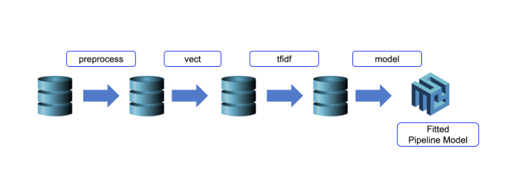

A Pipeline is specified as a sequence of stages, and each stage is either a Transformer or an Estimator. These stages are run in order, and the input DataFrame is transformed as it passes through each stage. That is, the data are passed through the fitted pipeline in order. Each stage’s transform() method updates the dataset and passes it to the next stage. With the help of Pipelines, we can ensure that training and test data go through identical feature processing steps.

Now let’s see how this can be done in Spark NLP using Annotators and Transformers. Assume that we have the following steps that need to be applied one by one on a data frame.

- Split text into sentences
- Tokenize

And here is how we code this pipeline up in Spark NLP.

**Let try entire SPAK pipe line on Data PUB MED Data**

- download: https://s3.amazonaws.com/auxdata.johnsnowlabs.com/public/resources/en/pubmed/pubmed-sample.csv

```python
#loading pub med data
import pyspark.sql.functions as F
pubMedDF = spark.read\
                .option("header", "true")\
                .csv("./Data/pubmed-sample.csv")\
                .filter("AB IS NOT null")\
                .withColumnRenamed("AB", "text")\
                .drop("TI").toDF("text")

pubMedDF.show(truncate=100,n=5)
```

```
+----------------------------------------------------------------------------------------------------+
|                                                                                                text|
+----------------------------------------------------------------------------------------------------+
|The human KCNJ9 (Kir 3.3, GIRK3) is a member of the G-protein-activated inwardly rectifying potas...|
|BACKGROUND: At present, it is one of the most important issues for the treatment of breast cancer...|
|OBJECTIVE: To investigate the relationship between preoperative atrialfibrillation and early and ...|
|Combined EEG/fMRI recording has been used to localize the generators of EEGevents and to identify...|
|Kohlschutter syndrome is a rare neurodegenerative disorder presenting withintractable seizures, d...|
+----------------------------------------------------------------------------------------------------+
only showing top 5 rows
```

```python
# defininng the pipe line with
from pyspark.ml import Pipeline
from sparknlp.base import *
from sparknlp.annotator import *

document_assembler = DocumentAssembler()\
    .setInputCol("text")\
    .setOutputCol("document")

sentence_detector = SentenceDetector()\
    .setInputCols(['document'])\
    .setOutputCol('sentences')

tokenizer = Tokenizer() \
    .setInputCols(["sentences"]) \
    .setOutputCol("token")

clinical_entity_extractor = TextMatcher() \
    .setInputCols(["document",'token'])\
    .setOutputCol("clinical_entities")\
    .setEntities("./Data/clinical_entities.txt")\
    .setCaseSensitive(False)\
    .setEntityValue('clinical_entity')

cancer_entity_extractor = TextMatcher() \
    .setInputCols(["document",'token'])\
    .setOutputCol("cancer_entities")\
    .setEntities("./Data/cancer_entities.txt")\
    .setCaseSensitive(False)\
    .setEntityValue('cancer_entity')

nlpPipeline = Pipeline(stages=[
                        document_assembler,
                        sentence_detector,
                        tokenizer,
                        clinical_entity_extractor,
                        cancer_entity_extractor
 ])

empty_df = spark.createDataFrame([['']]).toDF("text")
pipelineModel = nlpPipeline.fit(empty_df)
result_pipleline_df = pipelineModel.transform(pubMedDF)
```

```python
result_pipleline_df.select('clinical_entities.result','cancer_entities.result').show(n=5,truncate=50)
```

```
+--------------------------------------------------+--------------------------------------------------+
|                                            result|                                            result|
+--------------------------------------------------+--------------------------------------------------+
|[KCNJ9, GIRK, KCNJ9, diabetes mellitus, nucleot...|                                                []|
|                                                []|[breast cancer, therapy, monotherapy, therapy, ...|
|                                                []|                                                []|
|                                                []|                                                []|
|                                                []|                                                []|
+--------------------------------------------------+--------------------------------------------------+
only showing top 5 rows
```

### Finisher

At the end of each pipeline or any stage that was done by Spark NLP, you may want to get results out whether onto another pipeline or simply write them on disk. The Finisher annotator helps you to clean the metadata (if it’s set to true) and output the results into an array

If we just want the desired output column in the final dataframe, we can use Finisher to drop previous stages in the final output and get the `result` from the process.

This is very handy when you want to use the output from Spark NLP annotator as an input to another Spark ML transformer.

**Settable parameters are:**

- `setInputCols()`
- `setOutputCols()`
- `setCleanAnnotations(True)` -> Whether to remove intermediate annotations
- `setValueSplitSymbol(“#”)` -> split values within an annotation character
- `setAnnotationSplitSymbol(“@”)` -> split values between annotations character
- `setIncludeMetadata(False)` -> Whether to include metadata keys. Sometimes useful in some annotations.
- `setOutputAsArray(False)` -> Whether to output as Array. Useful as input for other Spark transformers.

```python
# defining finisher for regex matcher
regex_matcher = RegexMatcher()\
    .setInputCols(["document"])\
    .setStrategy("MATCH_ALL")\
    .setOutputCol("regex_matches")\
    .setExternalRules(path='./Data/regex_rules.txt', delimiter=',')

finisher = Finisher() \
    .setInputCols(["regex_matches"]) \
    .setIncludeMetadata(False) # set to False to remove metadata


nlpPipeline = Pipeline(stages=[
 documentAssembler,
 regex_matcher,
 finisher
 ])

empty_df = spark.createDataFrame([['']]).toDF("text")
pipelineModel = nlpPipeline.fit(empty_df)
match_df = pipelineModel.transform(pubMedDF)
match_df.show(truncate = 50,n=5)
```

```
+--------------------------------------------------+--------------------------------------------------+
|                                              text|                            finished_regex_matches|
+--------------------------------------------------+--------------------------------------------------+
|The human KCNJ9 (Kir 3.3, GIRK3) is a member of...|[inwardly, family, spansapproximately, byapprox...|
|BACKGROUND: At present, it is one of the most i...|[previously, previously, intravenously, previou...|
|OBJECTIVE: To investigate the relationship betw...|[renal failure, cardiac surgery, cardiac surger...|
|Combined EEG/fMRI recording has been used to lo...|[normally, significantly, effectively, analy, o...|
|Kohlschutter syndrome is a rare neurodegenerati...|                                          [family]|
+--------------------------------------------------+--------------------------------------------------+
only showing top 5 rows
```

### LightPipeline

- LightPipelines are Spark NLP specific Pipelines, equivalent to Spark ML Pipeline, but meant to deal with smaller amounts of data. They’re useful working with small datasets, debugging results, or when running either training or prediction from an API that serves one-off requests.
- Spark NLP LightPipelines are Spark ML pipelines converted into a single machine but the multi-threaded task, becoming more than 10x times faster for smaller amounts of data (small is relative, but 50k sentences are roughly a good maximum). To use them, we simply plug in a trained (fitted) pipeline and then annotate a plain text. We don't even need to convert the input text to DataFrame in order to feed it into a pipeline that's accepting DataFrame as an input in the first place. This feature would be quite useful when it comes to getting a prediction for a few lines of text from a trained ML model.

  **It is nearly 20x faster than using Spark ML Pipeline**
- `LightPipeline(someTrainedPipeline).annotate(someStringOrArray)`

More: https://medium.com/spark-nlp/spark-nlp-101-lightpipeline-a544e93f20f1

```python
# defining pipeline for litepipeline
document_assembler = DocumentAssembler()\
.setInputCol("text")\
.setOutputCol("document")

tokenizer = Tokenizer() \
    .setInputCols(["document"]) \
    .setOutputCol("token")

stemmer = Stemmer() \
    .setInputCols(["token"]) \
    .setOutputCol("stem")

lemmetizer = Lemmatizer() \
    .setInputCols(["token"]) \
    .setOutputCol("lem")

nlpPipeline = Pipeline(stages=[
 document_assembler,
 tokenizer,
 stemmer,
 ])

empty_df = spark.createDataFrame([[' ']]).toDF("text")
pipelineModel = nlpPipeline.fit(empty_df)
pipelineModel.transform(pubMedDF).show(truncate=25,n=5)
```

```
+-------------------------+-------------------------+-------------------------+-------------------------+
|                     text|                 document|                    token|                     stem|
+-------------------------+-------------------------+-------------------------+-------------------------+
|The human KCNJ9 (Kir 3...|[[document, 0, 956, Th...|[[token, 0, 2, The, [s...|[[token, 0, 2, the, [s...|
|BACKGROUND: At present...|[[document, 0, 1406, B...|[[token, 0, 9, BACKGRO...|[[token, 0, 9, backgro...|
|OBJECTIVE: To investig...|[[document, 0, 1527, O...|[[token, 0, 8, OBJECTI...|[[token, 0, 8, object,...|
|Combined EEG/fMRI reco...|[[document, 0, 1637, C...|[[token, 0, 7, Combine...|[[token, 0, 7, combin,...|
|Kohlschutter syndrome ...|[[document, 0, 253, Ko...|[[token, 0, 11, Kohlsc...|[[token, 0, 11, kohlsc...|
+-------------------------+-------------------------+-------------------------+-------------------------+
only showing top 5 rows
```

```python
#let's define lite pipeline
from sparknlp.base import LightPipeline
light_model = LightPipeline(pipelineModel)
light_result = light_model.annotate("John and Peter are brothers. However they don't support each other that much.")
light_result.keys()
```

```
dict_keys(['document', 'token', 'stem'])
```

**important note:** When you use Finisher in your pipeline, regardless of setting `cleanAnnotations` to False or True, LigtPipeline will only return the finished columns.

### Reference:

Spark NLP offers pre-trained models in 26 languages and all you need to do is to load the pre-trained model into your disk by specifying the model name and then configuring the model parameters as per your use case and dataset. Then you will not need to worry about training a new model from scratch and will be able to enjoy the pre-trained SOTA algorithms directly applied to your own data with transform().

In the official documentation, you can find detailed information regarding how these models are trained by using which algorithms and datasets.

- https://github.com/JohnSnowLabs/spark-nlp-workshop/tree/master/tutorials/Certification_Trainings
- https://github.com/JohnSnowLabs/spark-nlp-models
- https://nlp.johnsnowlabs.com/docs/en/models
- https://nlp.johnsnowlabs.com/docs/en/annotators
- https://nlp.johnsnowlabs.com/docs/en/licensed_annotators